# Thursday - Jumpstart 2025: Data Visualization

### 1c. Add trend line

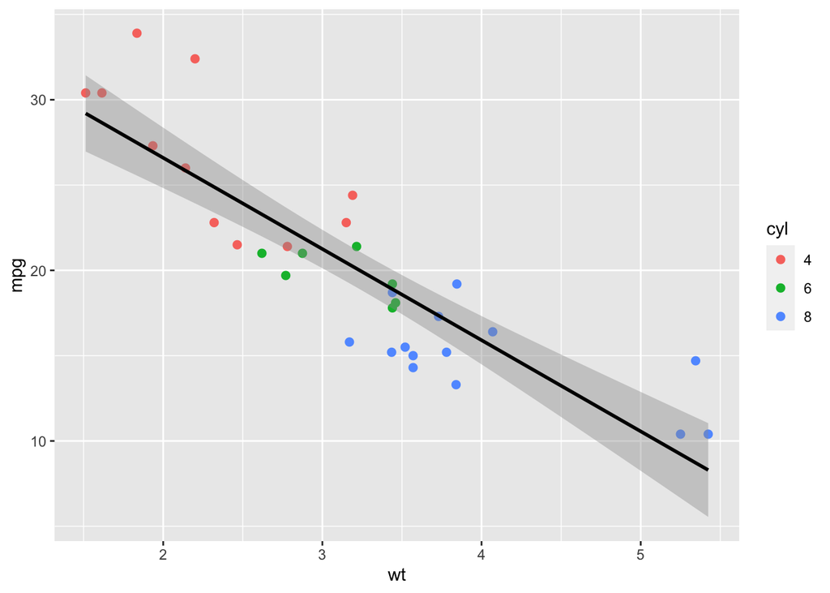

```r
# Add a regression line to show the overall relationship
ggplot(mtcars, aes(x = wt, y = mpg)) +
  geom_point(aes(color = cyl), size = 2) +
  geom_smooth(method = "lm", se = TRUE, color = "black")
```

### 1d. Professional labels and styling

```r
# Your code here: Add proper titles, labels, and professional styling
```

## Exercise 2: Bar Plot of Cylinder Distribution

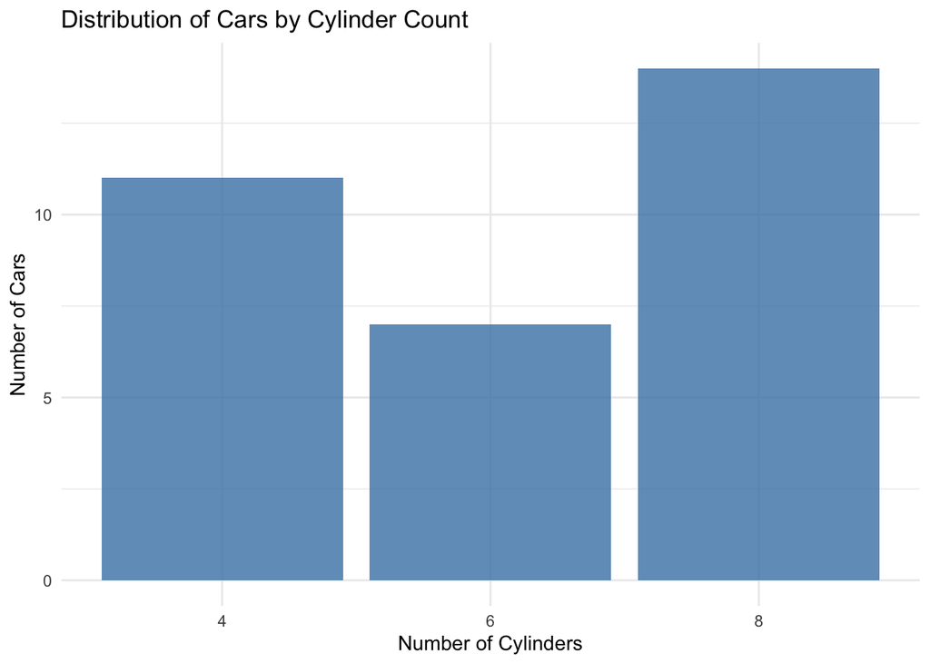

```r
# Create a bar plot showing the frequency of cars by cylinder count
ggplot(mtcars, aes(x = cyl)) +
  geom_bar(fill = "steelblue", alpha = 0.8) +
  labs(
    title = "Distribution of Cars by Cylinder Count",
    x = "Number of Cylinders",
    y = "Number of Cars"
  ) +
  theme_minimal()
```

## Exercise 3: Mean Comparison Plot

### 3a. Calculate average quarter-mile time by cylinder count

```r
# Calculate mean quarter-mile time (qsec) by cylinder count
average_qsec <- mtcars %>%
  group_by(cyl) %>%
  summarize(
    mean_qsec = mean(qsec, na.rm = TRUE),
    se_qsec = sd(qsec, na.rm = TRUE) / sqrt(n()),
    .groups = 'drop'
  )

print(average_qsec)
```

```
## # A tibble: 3 × 3
##   cyl   mean_qsec se_qsec
##   <fct>     <dbl>   <dbl>
## 1 4          19.1   0.507
## 2 6          18.0   0.645
## 3 8          16.8   0.320
```

### 3b. Create column plot with error bars

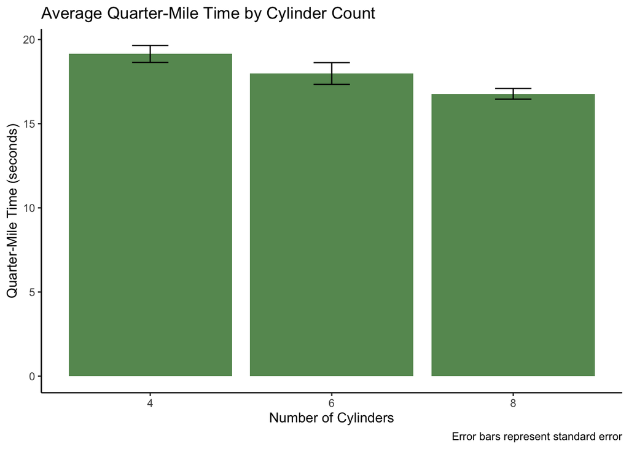

```r
# Plot average quarter-mile time by cylinder count
ggplot(average_qsec, aes(x = cyl, y = mean_qsec)) +
  geom_col(fill = "darkgreen", alpha = 0.7) +
  geom_errorbar(aes(ymin = mean_qsec - se_qsec, ymax = mean_qsec + se_qsec),
                width = 0.2) +
  labs(
    title = "Average Quarter-Mile Time by Cylinder Count",
    x = "Number of Cylinders",
    y = "Quarter-Mile Time (seconds)",
    caption = "Error bars represent standard error"
  ) +
  theme_classic()
```

## Exercise 4: Advanced Challenge

Create a comprehensive visualization that shows the relationship between horsepower (`hp`) and quarter-mile time (`qsec`), colored by transmission type (`am` where 0 = automatic, 1 = manual):

```r
# First, create a better transmission variable
mtcars <- mtcars %>%
  mutate(transmission = ifelse(am == 0, "Automatic", "Manual"))

# Your code here: Create an advanced plot with:
# - Scatter plot of hp vs qsec
# - Color by transmission type
# - Separate trend lines for each transmission type
# - Professional styling and labels
# - Proper title and caption
```

## Exercise 5: Faceted Analysis

Create a faceted plot showing the relationship between weight and fuel efficiency, separated by cylinder count:

```r
# Your code here: Create faceted scatter plots
```

# Saving and Exporting Plots

For academic publications, you’ll need to save high-quality versions of your plots:

```r
# Save plot as high-resolution PNG
ggsave("trust_by_age.png", width = 8, height = 6, dpi = 300)

# Save as PDF for publications
ggsave("trust_by_age.pdf", width = 8, height = 6)

# Save as SVG for web use
ggsave("trust_by_age.svg", width = 8, height = 6)
```

# Key Principles for Research Visualizations

## 1. **Clarity First**

- Clear visualizations help audiences understand patterns in data
- Always prioritize understanding over aesthetics
- Use descriptive titles and axis labels

## 2. **Appropriate Chart Types**

- **Scatter plots**: Relationships between continuous variables
- **Bar/Column plots**: Comparing categories or group means
- **Box plots**: Comparing distributions across groups
- **Histograms**: Understanding single variable distributions

## 3. **Honest Representation**

- Don’t manipulate scales to exaggerate effects
- Include confidence intervals and error bars when appropriate
- Clearly indicate sample sizes and data sources
- Make sure your axes start at 0 (or another reasonable point), and are the same across graphs

## 4. **Accessibility**

- Use colorblind-friendly palettes
- Provide alternative text descriptions
- Ensure sufficient contrast

## 5. **Publication Standards**

- Follow your target journal’s figure guidelines
- Include proper statistical information in captions
- Use consistent styling across all figures

## 6. **An Example**

- https://academic.oup.com/jcmc/article/29/1/zmad039/7394122

# What You’ve Accomplished Today

Excellent work! You’ve now mastered:

✅ **ggplot2 fundamentals** - grammar of graphics approach

✅ **Essential plot types** for research

✅ **Professional styling** for academic publications

✅ **Best practices** for honest, accessible visualization

## Your Visualization Toolkit:

- Scatter plots for relationships
- Bar plots for comparisons
- Histograms for distributions
- Box plots for group comparisons
- Faceted plots for complex analyses
- Professional themes and styling

## Resources for Continued Learning:

- [ggplot2 Reference](https://ggplot2.tidyverse.org/reference/)
- [R Graphics Cookbook](https://r-graphics.org/)
- [Data Visualization Best Practices](https://www.tableau.com/learn/articles/data-visualization)
- [Colorbrewer Palettes](https://colorbrewer2.org/)
- [Academic Figure Guidelines](https://www.nature.com/nature/for-authors/formatting-guide)

Great job building your data visualization skills! 📊✨